# Statistical Analysis of Weather Impacts on Bike Demand in Seoul!

by Group 34: Ella Hoang-Elcome, Lizzy Goh and Parinoor Sekhon

2026-11-28

## Research Question

Our research question, ‘To what extent can variation in bike demand throughout the year in Seoul be attributed to changes in weather?’ aims to explore and model how different weather related factors affect fluctuations in bike demand in Seoul from the given data frame. This question might be of interest to local governing bodies when designing infrastructure or bike sharing companies that might want to optimise pricing and distribution of bikes.

## Data

Our investigation uses the Seoul Bike Sharing Demand dataset by UC Irvine Machine Learning Repository with 14 variables and 8760 observations, consisting of readings over every hour of every day between the dates 01/12/2017 and 30/11/2018.

We used the following variables in the initial dataset in our exploration:

| Variable | Type | Description |
| --- | --- | --- |
| date | date | date when recordings with taken |
| rented_bike_count | integer | hourly number of rented bikes |
| hour | integer | hour of the day |
| temperature_c | continuous | recorded temperature in degrees celsius |
| humidity | integer | recorded humidity as a percentage |
| rainfall_mm | integer | recorded rainfall in millimetres |
| seasons | categorical | winter, spring, summer or autumn |
| solar_radiation | continuous | recorded solar radiation in megajoules per metre squared |

We derived the following variables to be use in our analysis:

[output not shown]

## Findings

### Assumptions and Limitations:

When importing the dataset from excel into the R Studio project, the Date variable data type was converted into string rather than retaining its original format, so we performed data cleaning and transformation (in the form of as.Date()) to ensure all variables were suitable for analysis and effective plotting of data.

Since we decided to measure the influence of predictors on a bike demand (a numerical variable), we were limited to using linear regression when it came to modelling as logistic regression is only suitable for predicting categorical variables.

During the exploration of the data it seemed there might be some anomalous values in our outcome variable, such as several days with a 0 rented bike count at all hours or some extremely high counts at some hours. However, after reviewing a boxplot below of all hourly rented bike counts, we decided to keep these values in our analysis as it would not make sense to remove the high bike counts.

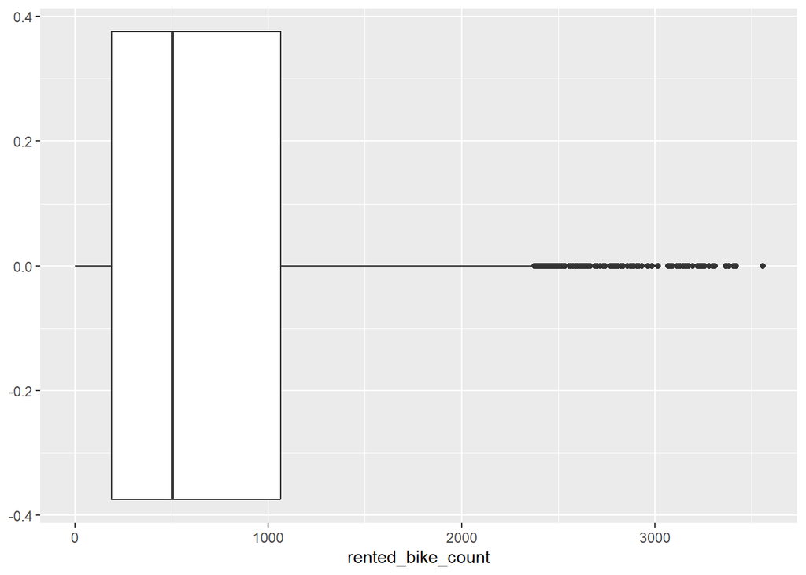

### Exploration & Visualisations:

#### 1. Temperature and Bike Demand

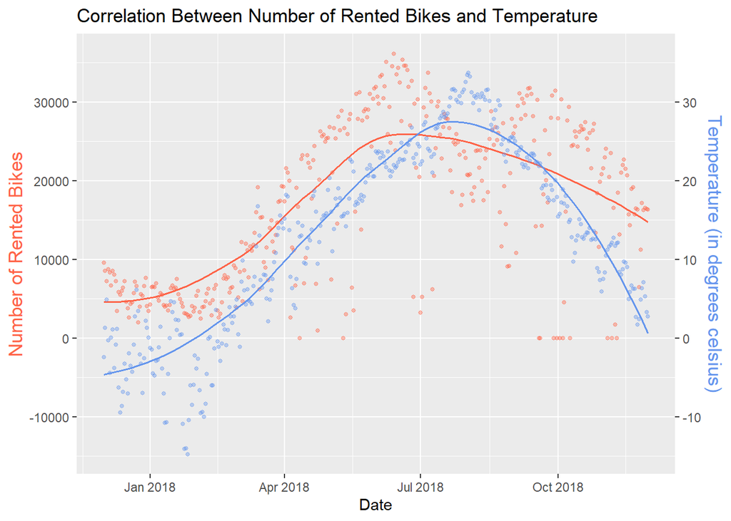

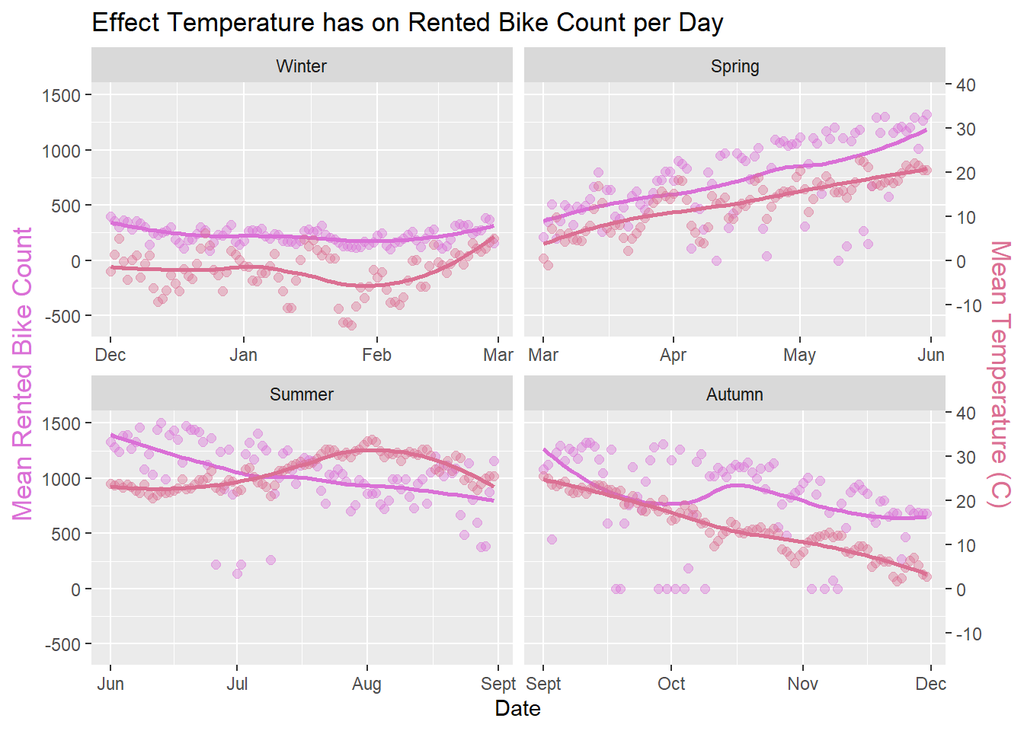

Both graphs illustrate the relationship between number of rented bikes and temperature throughout the year, except that Figure 1 examines the overall trend across the whole year whereas Figure 2 separates the data into four seasons, allowing seasonal variations to be explored and viewed in greater detail. Both graphs show that generally as temperature increases, so does bike demand implying that there is a relationship between warmer weather and greater demand for rental bikes.

Although the graphs suggest an association, this does not prove that temperature directly influences bike rental demand as correlation does not imply causation. The Pearson correlation coefficient for Figure 1 was calculated to be 0.69982 to 5 significant figures, suggesting a moderately strong linear relationship between the two variables, supporting the relationship deduced from the first graph; however the value is not strong enough for temperature to be the only variable affecting bike rental demand.

This can be further attested to by the graph below which measures the mean bike count for each temperature group:

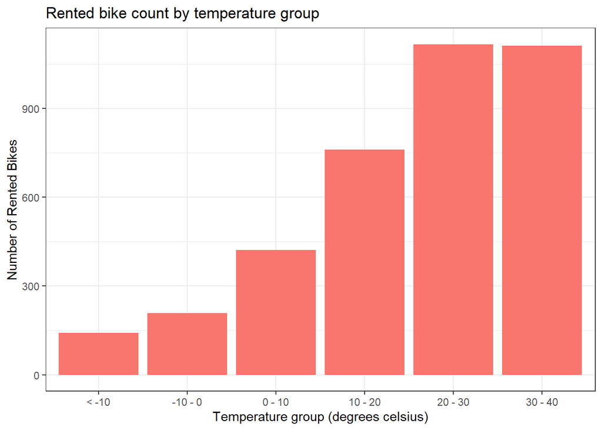

#### 2. Humidity and Bike Demand

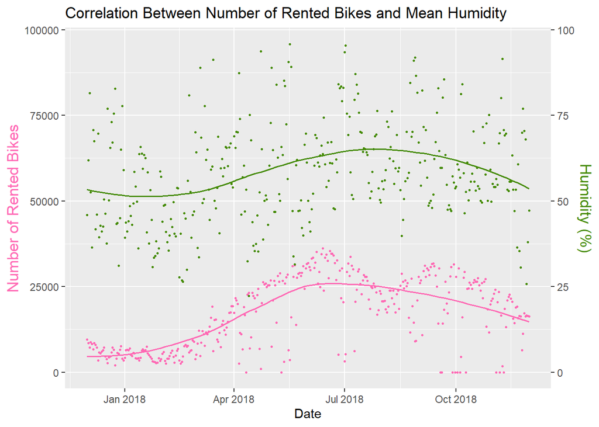

```
## # A tibble: 1 × 1
##   Correlation
##         <dbl>
## 1      0.0282
```

Here, we observed the relationship between the number of bikes rented daily and the mean humidity of that day. In the above figure, both graphs peak and fall at around the same time, following similar trends implying that as mean humidity increases the number of bikes demanded in a day increases as well. However, while the data points for the number of rented bikes remain, for the most part, close to their associated graph, we can see that the data points for humidity rarely follow the plotted line. This tells us that humidity does not follow a recognisable trend over the year leading its graph to be underfitted. Additionally, the pearson correlation coefficient of 0.028 tells us that there is a positive but very weak correlation between humidity and number of bikes demanded in a day.

#### 3. Rainfall and Bike Demand

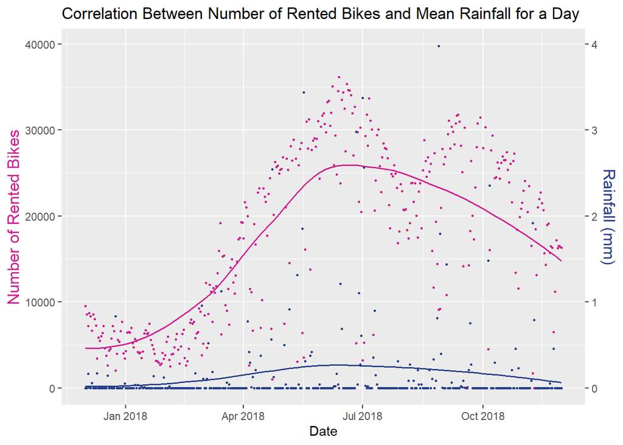

```
## # A tibble: 1 × 1
##   Correlation
##         <dbl>
## 1      -0.214
```

Above, we plotted the graphs for the number of rented bikes in a day and the mean rainfall for that day measured in millimeters. From the graphs it appears that there is no visible relationship between the demand for bikes and rainfall, as the demand rises and falls as rainfall remains almost constant at low levels with few exceptions. This is seen in a low Pearson correlation coefficient of -0.214 which tells us there is a negative and weak relationship between rainfall and bikes demanded. The boxplot below shows that most, if not, all of the non-zero values in the rainfall variable are anomalous, making it almost impossible to make a reliable model to predict bike count from rainfall. Hence, we decided not to include rainfall as a predictor in our models.

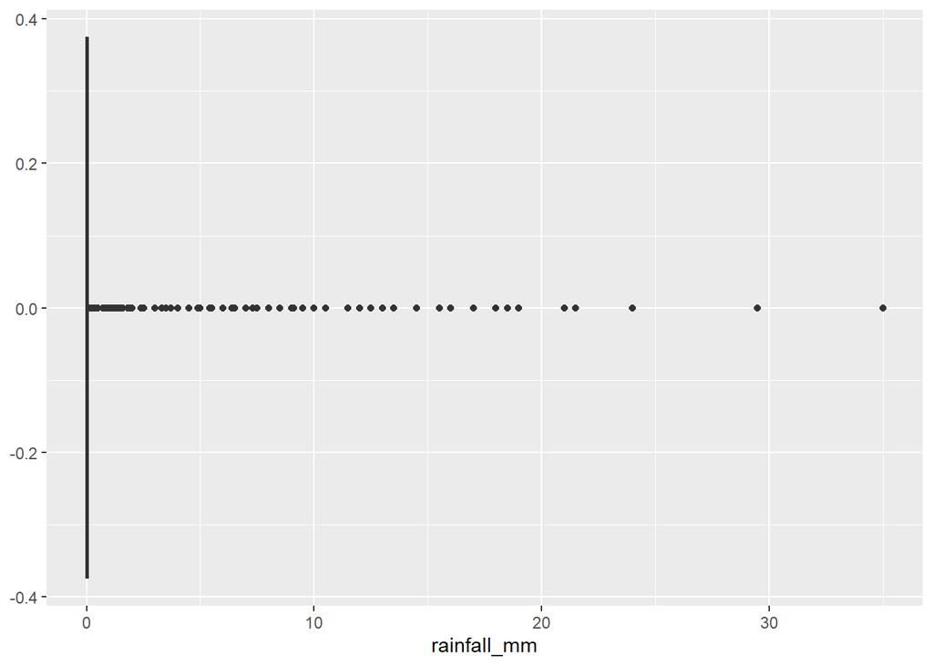

### Modelling:

#### 1. Multiple Predictors: Temperature, Humidity and Hours of Sunlight

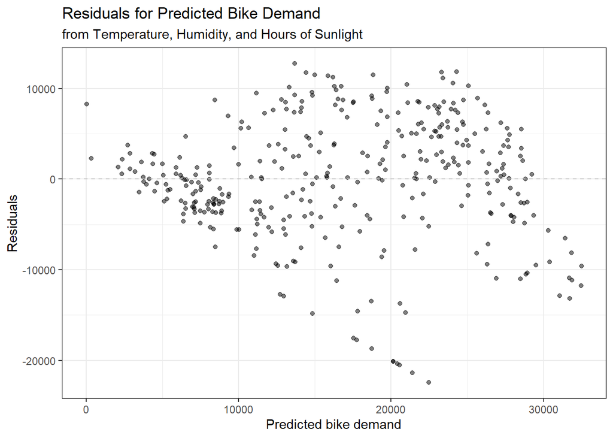

We modelled the demand for bikes using linear regression where temperature, humidity and hours of sunlight are predictors and we obtained the following equation:
$$D_E = 5188.0 + 540.0T_M - 177.7H_M + 1236.7S_H$$
Where:
$D_E =$ Estimated Daily Demand
$T_M =$ Mean Daily Temperature
$H_M =$ Mean Daily Humidity
$S_H =$ Daily Hours of Sunlight
From the residual plot we can see a pattern as predicted bike demand increases the residuals increase, implying that the model is not a good fit, additionally they are not randomly scattered around 0; so overall, this model might not be an ideal fit as we cannot accurately estimate the expected daily bike demand as there is a fan shape present in the residual plot which indicates that the assumption of constant variance is violated. Further down we explore more models as we try to find one with a suitable fit, so the adjusted R squared value must be used over the R squared value as it considers the number of predictors for complexity’s sake. As a result, the adjusted R squared value for the testing data for this model is 0.638 and the RMSE value for the testing data is 6285.3.

#### 2. Humidity as a Singular Predictor

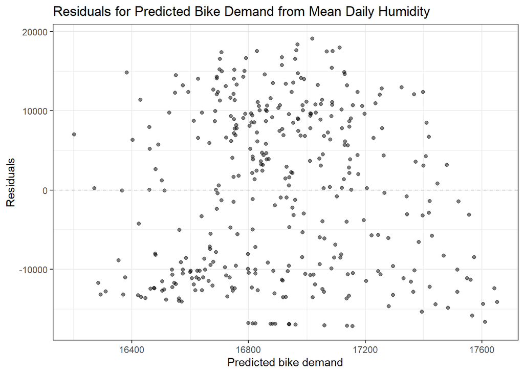

We also modelled the demand using only the humidity variable as a predictor. This gave the following equation:

$$D_E = 15764.1 + 16.7H_M$$

$D_E =$ Estimated Daily Demand  
$H_M =$ Mean Daily Humidity

The R squared value for this model is 0.0007 which is extremely low and shows that this model is not a good fit for predicting bike demand. Comparing the residual plot with the linear graph of humidity against actual daily bike demand we see that there is little to no correlation between the two. This led to the residuals being randomly scattered around zero with no discernible pattern.

#### 3. Sunlight as a Singular Predictor

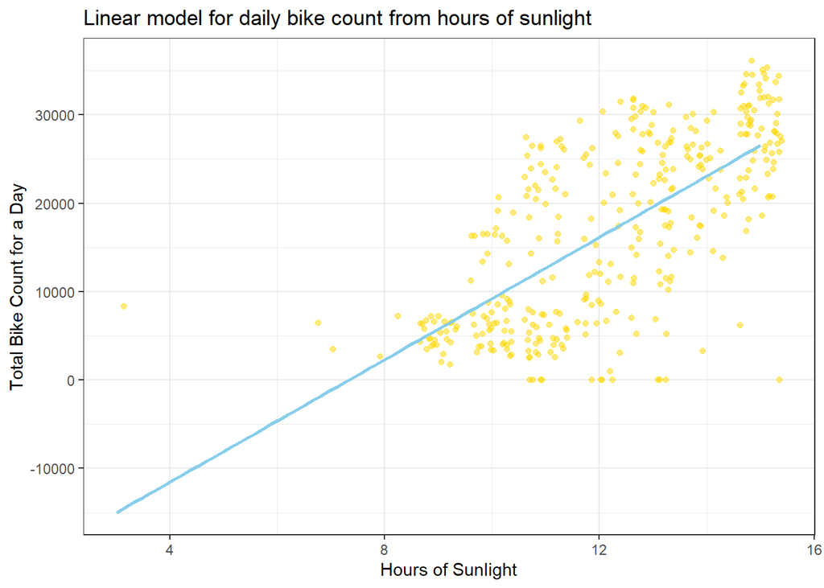

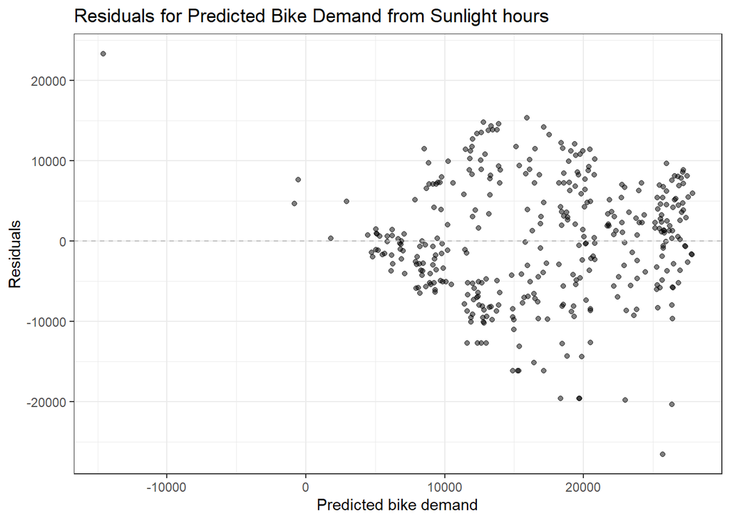

We also modelled the demand using only hours of sunlight as a predictor. This gave the following equation:
$$D_E = -25387.0 + 3461.6S_H$$

$D_E =$ Estimated Daily Demand  
$S_H =$ Daily Hours of Sunlight

## Ethics and Reproducibility

From the given data, we saw no immediate ethics concerns as none of the data is personal and only general readings such as demand count, temperature and more are utilised. Moreover, as we set a seed and make use of workflows, our models are easily reproducible as random processes such as splits produce consistent results every time our code is run.

## References

UC Irvine Machine Learning Repository. Seoul Bike Sharing Demand. Retrieved October 18, 2026, from https://archive.ics.uci.edu/dataset/560/seoul+bike+sharing+demand